# Analysis plan

Author

Andy Field

Published

July 21, 2026

```r
library(betareg)
library(brms)
library(easystats)
library(tidyverse)
#devtools::install_github("vdeminstitute/vdemdata")

# get some colours
turbo_8 <- scales::viridis_pal(option = "turbo", begin = 0.1, end = 0.9)(8)
```

## Coding frame

- drive.google.com/drive/u/1/folders/1yWJtaviS_1Xevwq9wmhBRTvkb6S8VQ4C

## Composite outcome measures

Many items can be distilled to a yes or no answer with no distinction between whether the information is in the main article or a supplement. In general, items and sub-items will be scored as 1 (yes) or 0 (no), with variants to this noted below.

- **Descriptive information about scale construction**: Questions 7, 8, 9, 10, and 11 relate to descriptions of how the scale development. For Q9 where there are multiple items under ‘yes’ these will be scored as 1 (selected) and 0 (not selected). Q10.5 will be scored as (2) ‘All items ..’, (1) ‘Example items …’ and (0) ‘No items …’. This will result in a total count from 0 (reported nothing) to 14 (reported everything that could feasibly be reported)[^1].
- **Participant descriptions**: Q12-Q14 relate to participant descriptions/missing data. Q12 has three sub-items scored in the normal way resulting (score range 0-3); Q13.2 scored treating location, administration and mode as sub-items so the range of scores will be 0-4. Q14 scored in the usual way. Potential range across these items is 0 (reported nothing) to 8 (reported everything).
- **Validity**: Q15.4 and Q15.5 each scored as 1 (they reported something) yielding a total ranging from 0 (not reported) to 2 (reported both convergent and discriminant).
- **Reliability**: Q15.3 scored as 1 for every item selected yielding a total ranging from 0 (nothing reported) to 4 (reported everything)[^2]
- **Dimensionality**: Different scores will be computed for EFA/PCA and CFA
  - **FA/PC Dimensionality**: If an EFA or PCA is reported then Q15.1 or Q15.3 items are summed (score 1 for everything selected) to yield a score from 0 to 10 (or more if multiple items are written in other)
  - **CFA Dimensionality**: For CFA Q15.2 items are summed (score 1 for everything selected) to yield a score from 0 to 6 (or more if multiple items are written in other)
- **Overall score (primary outcome)**: to compute an overall score, we will sum the aforementioned scores.

## Mahima’s Statistical models

### Primary analysis

The primary outcome will be the proportion of selected items on the coding scheme within each article. The outcomes are therefore proportions and a beta-regression model will be used (Ferrari and Cribari-Neto 2004; Geller et al. 2026; Smithson and Verkuilen 2006) with piecewise linear trends for pre and post-2014. Multiple measures may be reported within an article meaning that a given article might contribute several proportions. To account for this multilevel structure the model will include a random intercept for proportions (level 1) nested within articles (level 2).

The form of the model is

$$\begin{aligned}
g\left(\mu_{ij}\right) &= \ln\left(\frac{\mu_{ij}}{1-\mu_{ij}}\right) = \eta_{ij}\\
\eta_{ij} &= \left[\beta_{0} + \beta_1\text{time}_{i} + \beta_2\left(\text{time}_{i}-12\right)\times \text{era}_{i} \right] + \left[\mu_{0j} + \varepsilon_{ij}\right]
\end{aligned}$$

**NotePiecewise linear trends**

When `era` = 0 (pre-2014) the linear part of the model is:

$$\begin{aligned}
\eta_i &= \beta_{0} + \beta_1\text{time}_{i}
\end{aligned}$$

So $\beta_1$ is the slope for time for articles pre-2014.

When `era` = 1 (post-2014) the linear part of the model is:

$$\begin{aligned}
\eta_i &= \beta_{0} + \beta_1\text{time}_{i} + \beta_2\left(\text{time}_{i}-12\right) \\
&= \beta_{0} + \beta_1\text{time}_{i} + \beta_2\text{time}_{i}-12\beta_2 \\
&= \beta_{0} - 12\beta_2 + \left(\beta_1 + \beta_2\right)\text{time}_{i}
\end{aligned}$$

Which is a linear model of the form $y = \alpha + \beta x$ with intercept $\alpha = \beta_{0} - 12\beta_2$ and slope $\beta = \beta_1 + \beta_2$. Therefore the slope post 2014 ($\beta$) is the additive effect of the slope pre-2014 ($\beta_1$) and $\beta_2$. Put another way, $\beta_2$ is the *difference* in the slope at post-2014 compared to pre-2014.

Note also that these models are equivalent at 2014 (`time` = 12):

`era` = 0 (pre-2014):

$$\begin{aligned}
\eta_i &= \beta_{0} + 12\beta_1
\end{aligned}$$

`era` = 1 (post-2014):

$$\begin{aligned}
\eta_i &= \beta_{0} - 12\beta_2 + 12\left(\beta_1 + \beta_2\right) \\
&= \beta_{0} + 12\beta_1
\end{aligned}$$

in which:

- `time`: The variable `time` is coded such that 2002 is year zero and subsequent values represent the time since 2002.
- `era`: a dummy variable coded as 0 = pre-2014, and 1 = post-2014.
- $\beta_{0}$ is the mean proportion of items selected in 2002 (i.e.`time` and `era` = 0) in log odds units
- $\beta_{1}$ is the change in the log odds of the mean proportion

This model cannot accommodate 0 and 1 values. Although it seems highly unlikely that any article would receive proportions of 0 (no items selected on the coding scheme) or 1 (all items reported) if there are observed proportions of 0 and 1 we will fit a zero-and-one‐inflated beta (ZOIB) model in which zeros and 1s are modelled by estimating two extra parameters: the number of scores at these extremes ($\alpha$) and the proportion of these scores that are 1 ($\gamma$).

### Priors

#### Substantive parameters

The $\beta$s are in logit form. Given they represent changes in the slope and the outcome is on a 0-1 scale, the maximum plausible change must also lie on this scale.

Given the piecewise nature of the model, we can look at $\beta$ in terms of a rate over 12 time points. Let’s think first about $\beta$ if it were expressed in raw units (proportions). That is, $\beta = p_t - p_{t-1}$. If the proportion of items checked changed from 0 (no items) to 1 (all items), this would equate to a change of $\frac{1}{12} = 0.08$. We could treat this as an absolute maximum change in the proportion for every unit of time. The minimum change is, of course 0. Therefore, in raw units, $0 < |\beta| < 0.08$.

However, the $\beta$s in the beta model represent the change in the log odds, and not the change in the raw proportion. That is:

$$\begin{aligned}
\beta &= \ln\left(\frac{p_t}{1-p_t}\right) - \ln\left(\frac{p_{t-1}}{1-p_{t-1}}\right)
\end{aligned}$$

The minimum plausible absolute value is no change; that is

$$\begin{aligned}
\ln\left(\frac{p_t}{1-p_t}\right) &= \ln\left(\frac{p_{t-1}}{1-p_{t-1}}\right)
\end{aligned}$$

This will yield $\beta = 0$ and $OR = e^{\beta} = 1$. What about other potential changes? We can get a crude sense of the range of plausible values by plotting

$$\begin{aligned}
\beta = \ln\left(\frac{p_{t-1} + \delta}{1-p_{t-1} + \delta}\right) - \ln\left(\frac{p_{t-1}}{1-p_{t-1}}\right)
\end{aligned}$$

in which $\delta$ is the raw change in the initial proportion. Figure 1 shows values of $beta$ as a function of the raw change in the proportion ($\delta$) and the initial proportion ($p_{t-1}$). Even at the very extremes of what we might plausibly expect, we’re looking at $-2 < \beta < 2$ and we should constrain the prior accordingly.

However, we also don’t expect proportions to decrease. Pre-2014 we expect a fairly flat line (that is, no change in reporting), but post-2014 we expect a positive gradient. So our priors should lean towards positive values. Based on Figure 1, we might, for example, want to capture the range of $-0.04 < \delta < 0.08$, which equates to $-0.6 < \beta < 1.8$. Figure 2 shows a standard normal (orange). The shaded area represents the limits of plausible values of $beta$ from Figure 1. The standard normal $N(0, 1)$ is both too wide and centred lower than desirable. The blue curve shows $N(0.5, 0.25)$, which seems to provide good coverage of the shaded area.

For the intercept, we might reasonably expect people to report 25-75% of items. The most extreme values would be base rates of around 0.1 ($\beta_0 = \ln(\frac{0.1}{0.9}) = -2.2$) and 0.9 ($\beta_0 = \ln(\frac{0.9}{0.1}) = 2.2$). A $N(0, 3)$ distribution (green line in Figure 2) captures these extremes.

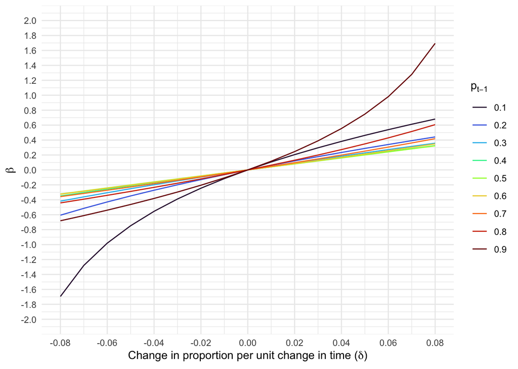

Figure 1

```r
lo_tib <- tibble(
  p1 = rep(seq(0.1, 0.9, 0.1), each = 17),
  delta = rep(seq(-0.08, 0.08, 0.01), 9),
  p1_log_odds = log(p1/(1-p1)),
  p2_log_odds = log((p1+delta)/(1-(p1+delta))),
  beta = p2_log_odds - p1_log_odds,
  OR = exp(beta)
  )


ggplot(data = lo_tib, aes(x = delta, y = beta, colour = as.factor(p1))) +
  geom_line() +
  coord_cartesian(ylim = c(-2, 2)) +
  scale_y_continuous(breaks = seq(-2, 2, 0.2)) +
  scale_x_continuous(breaks = seq(-0.08, 0.08, 0.02)) +
  scale_colour_viridis_d(option = "turbo") +
  labs(x = bquote("Change in proportion per unit change in time ("*delta*")"), y = bquote(beta), colour = bquote(p[t-1])) +
  theme_minimal()
```

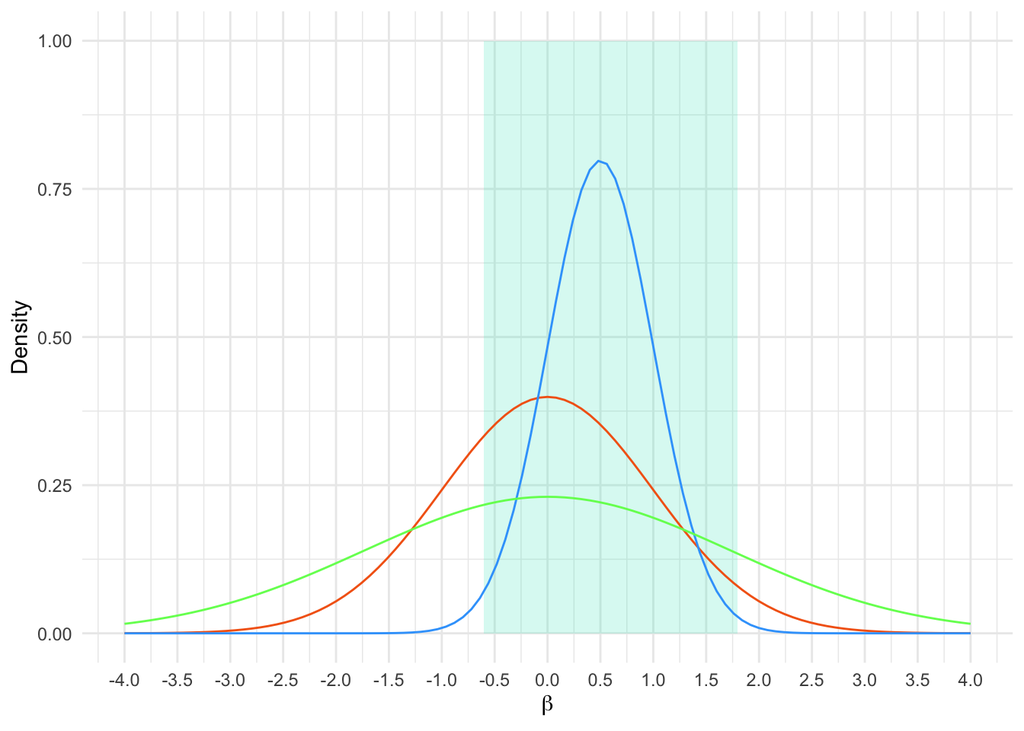

Figure 2

```r
ggplot(data = data.frame(x = c(-4, 4)), aes(x)) +
    geom_rect(aes(xmin = -0.6, xmax = 1.8, ymin = 0, ymax = 1), fill  = turbo_8[3], alpha = 0.1) +
  stat_function(fun = dnorm, n = 101, args = list(mean = 0, sd = 1), colour = turbo_8[7]) +
  stat_function(fun = dnorm, n = 101, args = list(mean = 0.5, sd = sqrt(0.25)), colour = turbo_8[2]) +
  stat_function(fun = dnorm, n = 101, args = list(mean = 0, sd = sqrt(3)), colour = turbo_8[4]) +
  scale_x_continuous(breaks = seq(-4, 4, 0.5)) +
  labs(x = bquote(beta), y = "Density") +
  theme_minimal()
```

```r
sim_dat <- function(b0, b1, steps = 12, plogis = F){
  dat <- tibble(
    t = 0:steps,
    p = seq(b0, b0+steps*b1, b1)
    )

  model_beta <- betareg(p ~ t | t,
                      data = dat,
                      link = "logit")

  if(plogis){
    plogis(coef(model_beta))
  } else {
    coef(model_beta)
  }
}


sim_dat(b0 = 0.1, b1 = 0.07)
sim_dat(b0 = 0.5, b1 = 0.04, plogis = T)
```

#### Random effects

The random intercept for article means that the variance of intercepts ($\sigma^2_{\mu_0}$) must be estimated. A noninformative prior (restricted to positive values) will be used to estimate this parameter because we have no substantive hypotheses or a priori information about its value.

### Secondary analysis

The same model will be fit for each sub-dimension separately (outcome is proportion of items selected):

- Descriptive information about scale construction
- Participant descriptions
- Validity and reliability (combined)
- Dimensionality: studies will be excluded if 15.1a, 15.1b and 15.1c were not selected

For these models there are no a priori expectations about the effects so weaker priors will be used for the betas. We will use $N(0, 1)$.

## Amelia’s Statistical models

The model fitted will be

$$\begin{aligned}
g\left(\mu_{ij}\right) &= \ln\left(\frac{\mu_{ij}}{1-\mu_{ij}}\right) = \eta_{ij}\\
\eta_{ij} &= \left[\beta_{0} + \beta_1\log(\text{JIF}_{i}) \right] + \left[\mu_{0j} + \varepsilon_{ij} \right]
\end{aligned}$$

The log of the JIF will be used because it is highly skewed. When log predictors are used the relationship between the odds ratio and $\beta$ is: [^3]

$$\begin{aligned}
OR_{ij} &= \left(\frac{x_i}{x_j}\right)^\beta
\end{aligned}$$

For example, if we want to look at the odds ratio associated with a doubling of the JIF we have:

$$\begin{aligned}
OR &= 2^\beta
\end{aligned}$$

If the JIF has no effect then $OR = 1$ and

$$\begin{aligned}
1 &= 2^\beta \\
\ln(1) &= \ln(2^\beta) \\
0 &= \beta\ln(2) \\
\beta &= 0
\end{aligned}$$

What’s the maximum effect we might expect from a doubling of the JIF? Theoretically we could go from a proportion of 0 to 1 but this wouldn’t happen in practice. A huge effect would be a change in proportion of 0.5. This equates to between 14 to 19 additional items being checked on the coding scheme. Using $p_{t-1} = 0.25$ and $p_{t} = 0.25 + 0.5 = 0.75$ this yields an odds ratio of

$$\begin{aligned}
OR &= \frac{\frac{p_t}{1-p_t}}{\frac{p_{t-1}}{1-p_{t-1}}} = \frac{p_t}{1-p_t}\times\frac{1-p_{t-1}}{p_{t-1}} \\
&= \frac{0.75}{0.25}\times\frac{0.75}{0.25} \\
&= 9
\end{aligned}$$

If we expect this massive change from a doubling of the JIF we get

$$\begin{aligned}
9 &= 2^\beta \\
\ln(9) &= \ln(2^\beta) \\
\beta &= \frac{\ln(9)}{\ln(2)} \\
&= 3.17
\end{aligned}$$

Remembering we have no prediction about whether JIF will improve or harm reporting (many high JIF papers restricts words), we should centre the prior on 0 and have it capture at the very extremes $\beta = \pm 3.17$. A standard normal ($N(0,1)$) seems to capture this range and be weakly informative (orange line in Figure 3).

For the intercept, we might reasonably expect people to report 25-75% of items. The most extreme values would be base rates of around 0.1 ($\beta_0 = \ln(\frac{0.1}{0.9}) = -2.2$) and 0.9 ($\beta_0 = \ln(\frac{0.9}{0.1}) = 2.2$). A $N(0, 3)$ distribution (blue line in Figure 3) captures these extremes.

The random intercept for article means that the variance of intercepts ($\sigma^2_{\mu_0}$) must be estimated. A noninformative prior (restricted to positive values) will be used to estimate this parameter because we have no substantive hypotheses or a priori information about its value.

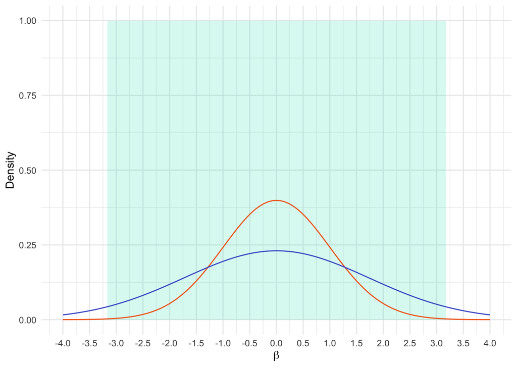

Figure 3

```r
ggplot(data = data.frame(x = c(-4, 4)), aes(x)) +
    geom_rect(aes(xmin = -3.17, xmax = 3.17, ymin = 0, ymax = 1), fill  = turbo_8[3], alpha = 0.1) +
  stat_function(fun = dnorm, n = 101, args = list(mean = 0, sd = 1), colour = turbo_8[7]) +
  stat_function(fun = dnorm, n = 101, args = list(mean = 0, sd = sqrt(3)), colour = turbo_8[1]) +
  scale_x_continuous(breaks = seq(-4, 4, 0.5)) +
  labs(x = bquote(beta), y = "Density") +
  theme_minimal()
```

## References

Ferrari, Silvia, and Francisco Cribari-Neto. 2004. “Beta Regression for Modelling Rates and Proportions.” *Journal of Applied Statistics* 31 (7): 799–815. https://doi.org/10.1080/0266476042000214501.

Geller, Jason, Matti Vuorre, Robert Kubinec, and Chelsea Parlett Pelleriti. 2026. *Jgeller112/Beta_regression_tutorial: RR Resubmission*. Zenodo. https://doi.org/10.5281/zenodo.20127600.

Smithson, Michael, and Jay Verkuilen. 2006. “A Better Lemon Squeezer? Maximum-Likelihood Regression with Beta-Distributed Dependent Variables.” *Psychological Methods* 11 (1): 54–71. https://doi.org/10.1037/1082-989X.11.1.54.

## Footnotes

[^1]: technically the score could be higher if multiple things are coded under other in Q9, but this is unlikely in practice
[^2]: technically the score could be higher if multiple things are mentioned under ‘other’
[^3]: see https://stats.stackexchange.com/questions/8318/interpretation-of-log-transformed-predictors-in-logistic-regression